# Transit-Oriented Development in Washington, DC

Al-Jalil Gault, Master of City Planning, ’21

## Introduction

As 21st century cities continue to grow, they must develop sustainable transportation systems. One strategy to achieve this is to promote Transit-Oriented Development (TOD). TOD involves promoting denser, mixed use development (such as housing, retail, restaurants, hospitals, and other services occupying shared sites) near transit. The goal of TOD is to increase access to these uses by using a city’s public transportation systems.

This project analyses the nature of development near transit stations in Washington, DC, and makes recommendations for a more sustainable, equitable system.

This study begins by installing libraries, establishing map themes, creating functions, and downloading census data.

```r
#here, we load all libraries of use in this project.
library(tidyverse)
library(tidycensus)
library(sf)
library(kableExtra)
library(rmdformats)
library(pander)

options(scipen=999)
options(tigris_class = "sf")
options(knitr.table.format = "html")

#aditionally, we will load all map themes and functions used in this project.
# ---- Load Styling options -----

mapTheme <- function(base_size = 12) {
  theme(
    text = element_text( color = "black"),
    plot.title = element_text(size = 16,colour = "black"),
    plot.subtitle=element_text(face="italic"),
    plot.caption=element_text(hjust=0),
    axis.ticks = element_blank(),
    panel.background = element_blank(),axis.title = element_blank(),
    axis.text = element_blank(),
    axis.title.x = element_blank(),
    axis.title.y = element_blank(),
    panel.grid.minor = element_blank(),
    strip.text.x = element_text(size = 14))
}

plotTheme <- function(base_size = 12) {
  theme(
    text = element_text( color = "black"),
    plot.title = element_text(size = 16,colour = "black"),
    plot.subtitle = element_text(face="italic"),
    plot.caption = element_text(hjust=0),
    axis.ticks = element_blank(),
    panel.background = element_blank(),
    panel.grid.major = element_line("grey80", size = 0.1),
    panel.grid.minor = element_blank(),
    strip.background = element_rect(fill = "grey80", color = "white"),
    strip.text = element_text(size=12),
    axis.title = element_text(size=12),
    axis.text = element_text(size=10),
    plot.background = element_blank(),
    legend.background = element_blank(),
    legend.title = element_text(colour = "black", face = "italic"),
    legend.text = element_text(colour = "black", face = "italic"),
    strip.text.x = element_text(size = 14)
  )
}

# Load Quantile break functions

qBr <- function(df, variable, rnd) {
  if (missing(rnd)) {
    as.character(quantile(round(df[[variable]],0),
                          c(.01,.2,.4,.6,.8), na.rm=T))
  } else if (rnd == FALSE | rnd == F) {
    as.character(formatC(quantile(df[[variable]]), digits = 3),
                 c(.01,.2,.4,.6,.8), na.rm=T)
  }
}

q5 <- function(variable) {as.factor(ntile(variable, 5))}

#Load Quantile break functions

## Geom_line Plot showing mean rent as a function of distance to metro stops
multipleRingBuffer <- function(inputPolygon, maxDistance, interval)
{
  #create a list of distances that we'll iterate through to create each ring
  distances <- seq(0, maxDistance, interval)
  #we'll start with the second value in that list - the first is '0'
  distancesCounter <- 2
  #total number of rings we're going to create
  numberOfRings <- floor(maxDistance / interval)
  #a counter of number of rings
  numberOfRingsCounter <- 1
  #initialize an otuput data frame (that is not an sf)
  allRings <- data.frame()

  #while number of rings  counteris less than the specified nubmer of rings
  while (numberOfRingsCounter <= numberOfRings)
  {
    #if we're interested in a negative buffer and this is the first buffer
    #(ie. not distance = '0' in the distances list)
    if(distances[distancesCounter] < 0 & distancesCounter == 2)
    {
      #buffer the input by the first distance
      buffer1 <- st_buffer(inputPolygon, distances[distancesCounter])
      #different that buffer from the input polygon to get the first ring
      buffer1_ <- st_difference(inputPolygon, buffer1)
      #cast this sf as a polygon geometry type
      thisRing <- st_cast(buffer1_, "POLYGON")
      #take the last column which is 'geometry'
      thisRing <- as.data.frame(thisRing[,ncol(thisRing)])
      #add a new field, 'distance' so we know how far the distance is for a give ring
      thisRing$distance <- distances[distancesCounter]
    }


    #otherwise, if this is the second or more ring (and a negative buffer)
    else if(distances[distancesCounter] < 0 & distancesCounter > 2)
    {
      #buffer by a specific distance
      buffer1 <- st_buffer(inputPolygon, distances[distancesCounter])
      #create the next smallest buffer
      buffer2 <- st_buffer(inputPolygon, distances[distancesCounter-1])
      #This can then be used to difference out a buffer running from 660 to 1320
      #This works because differencing 1320ft by 660ft = a buffer between 660 & 1320.
      #bc the area after 660ft in buffer2 = NA.
      thisRing <- st_difference(buffer2,buffer1)
      #cast as apolygon
      thisRing <- st_cast(thisRing, "POLYGON")
      #get the last field
      thisRing <- as.data.frame(thisRing$geometry)
      #create the distance field
      thisRing$distance <- distances[distancesCounter]
    }

    #Otherwise, if its a positive buffer
    else
    {
      #Create a positive buffer
      buffer1 <- st_buffer(inputPolygon, distances[distancesCounter])
      #create a positive buffer that is one distance smaller. So if its the first buffer
      #distance, buffer1_ will = 0.
      buffer1_ <- st_buffer(inputPolygon, distances[distancesCounter-1])
      #difference the two buffers
      thisRing <- st_difference(buffer1,buffer1_)
      #cast as a polygon
      thisRing <- st_cast(thisRing, "POLYGON")
      #geometry column as a data frame
      thisRing <- as.data.frame(thisRing[,ncol(thisRing)])
      #add teh distance
      thisRing$distance <- distances[distancesCounter]
    }

    #rbind this ring to the rest of the rings
    allRings <- rbind(allRings, thisRing)
    #iterate the distance counter
    distancesCounter <- distancesCounter + 1
    #iterate the number of rings counter
    numberOfRingsCounter <- numberOfRingsCounter + 1
  }

  #convert the allRings data frame to an sf data frame
  allRings <- st_as_sf(allRings)
}

# Load census API key

census_api_key("0d04e8a682958c8f02859af22fbbe2c30aafc70b", overwrite = TRUE, install = TRUE)
```

```r
readRenviron("~/.Renviron")
```

## Downloading Data

In this Analysis, we want to analyze the relationship between TOD and four factors: - Population Density - Median Household Invome - Median Rent - Commute Times to Work

We can download all of this information from the US Census. Below, we download Census data from 2009 and 2017 and combine it into one data frame. Here, we’re downloading data for Population, Median Household Income, Rent, and Commute times. We will calculate density later.

```r
# ---- Year 2009 tracts -----

# Our analysis focuses on four census variables for Washington D.C. in 2009

tracts09 <-
  get_acs(geography = "tract", variables = c("B25026_001E", #Population
                                             "B19013_001E", #Median Household Income (MedHHInc)
                                             "B25058_001E", #Median Rent
                                             "B08303_001E", #Count for population reporting commute time

                                             # Counts for those with commute times greater than 30 minutes
                                             "B08303_008E",
                                             "B08303_009E",
                                             "B08303_010E",
                                             "B08303_011E",
                                             "B08303_012E",
                                             "B08303_013E"),
                year=2009, state= 11, county=001, geometry=T) %>%
  st_transform('ESRI:102728')
```

```r
# Let's "spread" the data into wide form

tracts09 <-
  tracts09 %>%
  dplyr::select( -NAME, -moe) %>%
  spread(variable, estimate) %>%
  dplyr::select(-geometry) %>%

  rename(TotalPop = B25026_001, #rename variables into comprehensible names
         MedHHInc = B19013_001,
         MedRent = B25058_001,
         TravelPop = B08303_001)

# Let's create new rate variable for commute time using mutate
tracts09 <-
  tracts09 %>%
  mutate(pct30_TravelTime =  ifelse(TravelPop > 0, (B08303_008 +
                                                    B08303_009 +
                                                    B08303_010 +
                                                    B08303_011 +
                                                    B08303_012 +
                                                    B08303_013) / TravelPop, 0),
         year = "2009") %>%
  dplyr::select(GEOID, TotalPop, MedRent, MedHHInc, pct30_TravelTime, year)

# ---- 2017 Census Data -----
tracts17 <-
  get_acs(geography = "tract", variables = c("B25026_001E", #Population
                                             "B19013_001E", #Median Household Income (MedHHInc)
                                             "B25058_001E", #Median Rent
                                             "B08303_001E", #Count for population reporting commute time

                                             # Counts for those with commute times greater than 30 minutes
                                             "B08303_008E",
                                             "B08303_009E",
                                             "B08303_010E",
                                             "B08303_011E",
                                             "B08303_012E",
                                             "B08303_013E"),
          year=2017, state=11, county=001, geometry=T, output="wide") %>% #output=wide automatically downloads data in wide form
  st_transform('ESRI:102728') %>%

   rename(TotalPop = B25026_001E, #rename variables into comprehensible names
         MedHHInc = B19013_001E,
         MedRent = B25058_001E,
         TravelPop = B08303_001E) %>%

  # Let's create new rate variable for commute time using mutate
  mutate(pct30_TravelTime =  ifelse(TravelPop > 0, (B08303_008E +
                                                      B08303_009E +
                                                      B08303_010E +
                                                      B08303_011E +
                                                      B08303_012E +
                                                      B08303_013E) / TravelPop, 0),

         year = "2017") %>%
  dplyr::select(GEOID, TotalPop, MedRent, MedHHInc, pct30_TravelTime, year)
```

```r
# --- Combining 09 and 17 data  ----

allTracts <- rbind(tracts09,tracts17) %>%
  mutate(MedRent.inf = ifelse(year == "2009", MedRent * 1.14, MedRent)) #adjust rent for inflation to 2017 dollars
```

Next, we will download all Metro stops in Washington, DC.

```r
metroStops <- #brings in DC Metro stops
    st_read("https://opendata.arcgis.com/datasets/54018b7f06b943f2af278bbe415df1de_52.geojson") %>%
  st_transform(st_crs(tracts09))
```

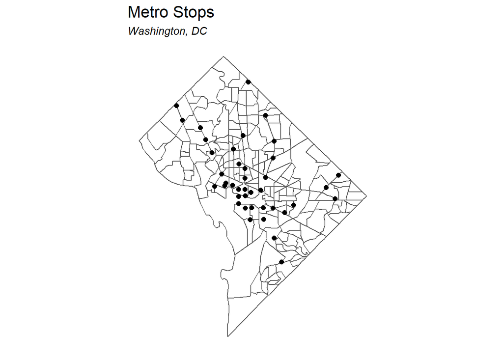

```r
# Let's visualize it

ggplot() +
  geom_sf(data=tracts17, fill="white") +
  geom_sf(data=metroStops,
          show.legend = "point", size= 2) +
  labs(title="Metro Stops",
       subtitle="Washington, DC") +
  mapTheme()
```

## Identifying TOD

Now that we have downloaded Metro Stops, we can determine whoch cenus tracts can be classified as having “Transit Oriented Development”. For the purposes of this study, we’ve defined potential of TOD as development within .5 miles of a Metro Stop.

Because we want to compare multiple variables, we’ve decided to constrain ourselves to consistent “Units of analysis”, which will be a Census Tract. If the center of a census tract is within .5 miles of a Metro Station, we will consider that tract as having TOD. If a census tract’s centroid is beyond .5 miles of a Metro Station, we will consider that tract as Non-TOD. One of the drawbacks of this method is that we potentially leave out development near transit that is close to a transit station, and we may inadvertently include data that might be far from transit (even though its census tract’s centroid is close to transit).

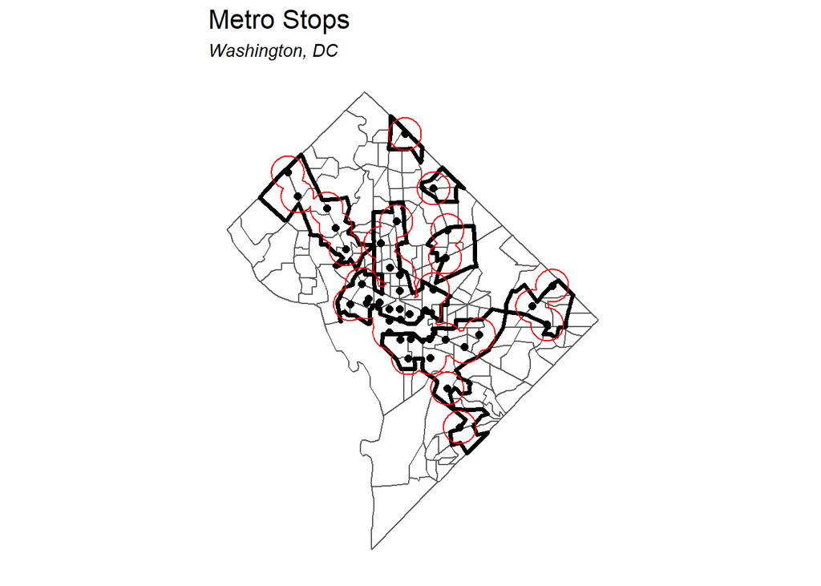

```r
#create a .5 mile buffer around Metro Stops.
buffer <-
    st_union(st_buffer(metroStops, 2640)) %>%
      st_sf() %>%
      mutate(Legend = "Unioned Buffer")

# Determine the 2009 tracts that have their centroid in the buffer
selectCentroids <-
  st_centroid(tracts09)[buffer,] %>%
  st_drop_geometry() %>%
  left_join(dplyr::select(tracts09, GEOID)) %>%
  st_sf() %>%
  dplyr::select(GEOID, TotalPop) %>%
  mutate(Selection_Type = "Select by Centroids")

#create an outline for TOD tracts
TOD_outline <- st_union(selectCentroids)

#visualize selected tracts
ggplot() +
  geom_sf(data=tracts17, fill="white") +
  geom_sf(data = TOD_outline, size = 1.25, color = "black", fill = NA ) +
  geom_sf(data = buffer, size = .5, color = "red", fill = NA) +
  geom_sf(data=metroStops,
          show.legend = "point", size= 2) +
  labs(title="Metro Stops",
       subtitle="Washington, DC") +
  mapTheme()
```

```r
# We then determine the centroids from the allTracts dataframe, which include data from both 2009 and 2017
# and create a column "TOD" that identifies the tracts that have centroids within the buffer as "TOD" and
# the remaining tracts as "non-TOD"

allTracts.group <-
  rbind(
    st_centroid(allTracts)[buffer,] %>%
      st_drop_geometry() %>%
      left_join(allTracts) %>%
      st_sf() %>%
      mutate(TOD = "TOD"),
    st_centroid(allTracts)[buffer, op = st_disjoint] %>%
      st_drop_geometry() %>%
      left_join(allTracts) %>%
      st_sf() %>%
      mutate(TOD = "Non-TOD"))
```

## Analyzing Indicators: Density, Rent, Median Income, and Commute Time

Next we plot four maps, which visualize relationships between population density, rent, median household income and travel time to work as it relates to Transit-Oriented Development.

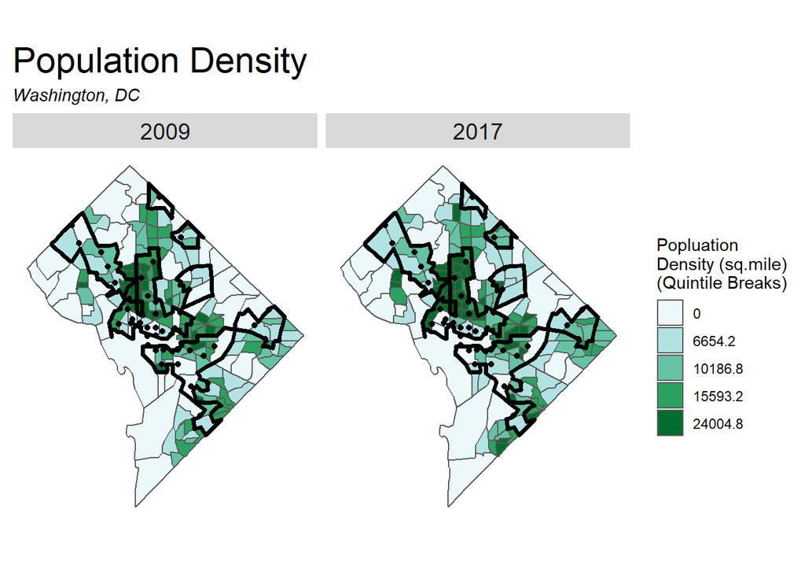

```r
## -- Population Density Plot -- ##

#first, we must create an attribute for population density by census tract

allTracts.group$Totalarea <- st_area(allTracts.group$geometry) #calculate the area of a census tract
allTracts.group$Totalarea_Miles <- allTracts.group$Totalarea / 27878400 #convert the area into units of miles
allTracts.group$PopDens <- allTracts.group$TotalPop / allTracts.group$Totalarea_Miles #calculate density as population/area

PopDensityMaps <-
  ggplot() +
  geom_sf(data = allTracts.group, aes(fill = q5(PopDens))) +
  geom_sf(data = TOD_outline, size = 1.25, color = "black", fill = NA) +
  geom_sf(data = metroStops) +
  facet_wrap(~year) +
  scale_fill_manual(values = c("#edf8fb", "#b2e2e2", "#66c2a4", "#2ca25f", "#006d2c"),
                    name = "Popluation \nDensity (sq.mile)\n(Quintile Breaks)",
                    labels = qBr(allTracts.group, "PopDens")) +
  labs(title = "Population Density", subtitle = "Washington, DC") +
  mapTheme() + theme(plot.title = element_text(size=22))
PopDensityMaps
```

By looking at the populaiton density map, census tracts with the highest population densities appeat to be located near transit as a TOD tract. This is a great indicaiton that Washing, DC’s transportation system promotes sustainable development.

### Policy Suggestion

In order to enhance the sustainability of it’s transportation system, policy makers should increase development near transit in the southeastern and northwestern parts of the city. Stations in these regions have less population density that that of stations directly north of the city center.

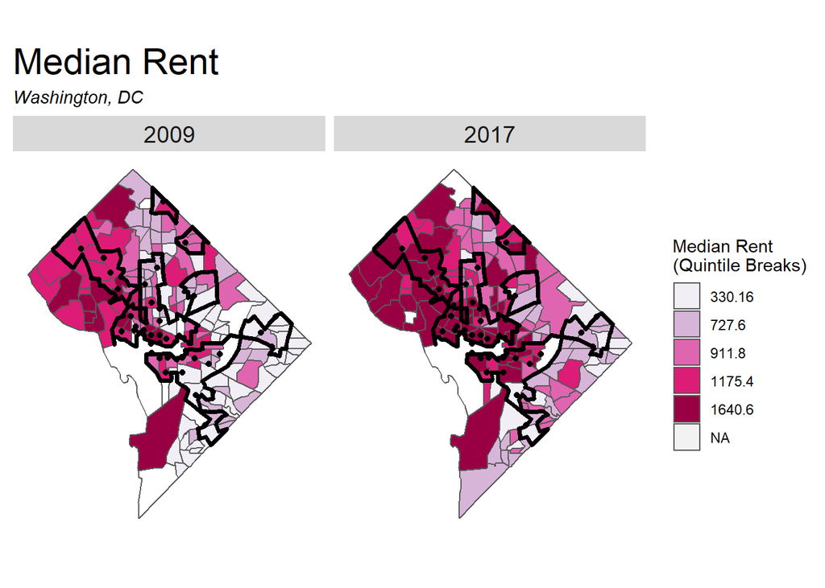

```r
## -- Rent Plot -- ##

RentMaps <-
  ggplot() +
  geom_sf(data = allTracts.group, aes(fill = q5(MedRent.inf))) +
  geom_sf(data = TOD_outline, size = 1.25, color = "black", fill = NA)  +
  geom_sf(data = metroStops) +
  facet_wrap(~year) +
  scale_fill_manual(values = c("#f1eef6", "#d7b5d8", "#df65b0", "#dd1c77", "#980043"),
                    name = "Median Rent\n(Quintile Breaks)",
                    labels = qBr(allTracts.group, "MedRent")) +
  labs(title = "Median Rent", subtitle = "Washington, DC") +
  mapTheme() + theme(plot.title = element_text(size=22))
RentMaps
```

### Policy Suggestion

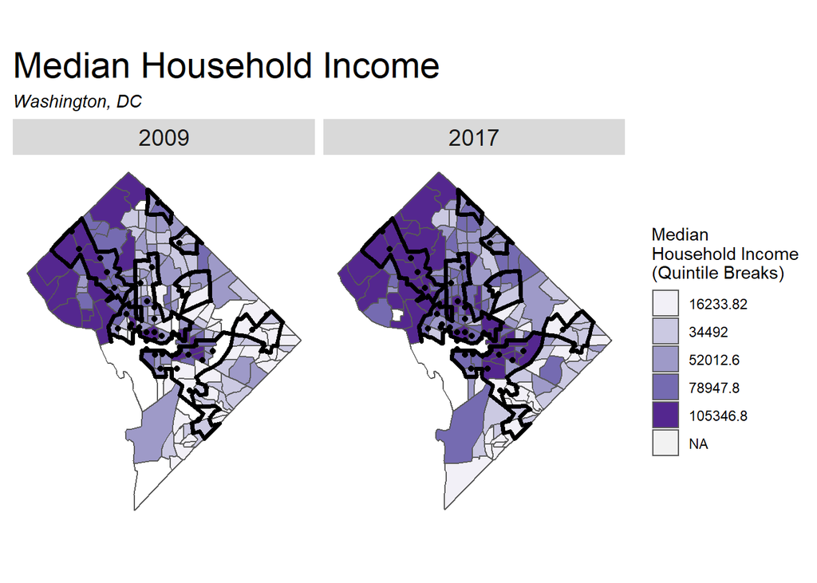

```r
## -- Median Household Income Plot -- ##

MedIncMaps <-
  ggplot() +
  geom_sf(data = allTracts.group, aes(fill = q5(MedHHInc))) +
  geom_sf(data = TOD_outline, size = 1.25, color = "black", fill = NA) +
  geom_sf(data = metroStops) +
  facet_wrap(~year) +
  scale_fill_manual(values = c("#f2f0f7", "#cbc9e2", "#9e9ac8", "#756bb1", "#54278f"),
                    name = "Median \nHousehold Income\n(Quintile Breaks)",
                    labels = qBr(allTracts.group, "MedHHInc")) +
  labs(title = "Median Household Income", subtitle = "Washington, DC") +
  mapTheme() + theme(plot.title = element_text(size=22))
MedIncMaps
```

### Policy Suggestion

Median Household Income tends to be highest near transit. This suggests that poorer individuals and families have diminished acces to transit. In order to compensate for inequities, policy makers should prioritise connecting poorer communities to the closet transit stations with other transportaiton modes, including:

- bikeshare expansion and investments
- price control for rideshare to and from these areas
- rapid bus routes that link citizens to metro stops nearby.

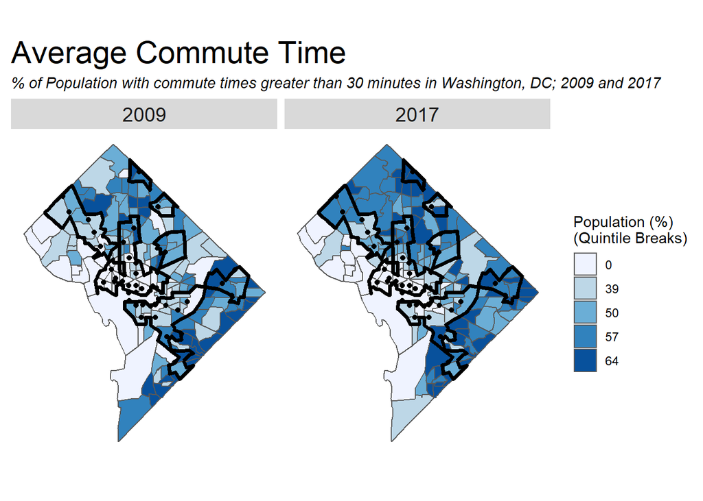

```r
## -- Travel Time Plot -- ##

#first, we create an attribute to represent the legend as anumber on a scale from 1 - 100
allTracts.group$pct30_TravelTime_pct <- allTracts.group$pct30_TravelTime*100

TravelTimeMaps <-
  ggplot() +
  geom_sf(data = allTracts.group, aes(fill = q5(pct30_TravelTime))) +
  geom_sf(data = TOD_outline, size = 1.25, color = "black", fill = NA) +
  geom_sf(data = metroStops) +
  facet_wrap(~year) +
  scale_fill_manual(values = c("#eff3ff", "#bdd7e7", "#6baed6", "#3182bd", "#08519c"),
                    name = "Population (%)\n(Quintile Breaks)",
                    labels = qBr(allTracts.group, "pct30_TravelTime_pct"))+
  labs(title = "Average Commute Time", subtitle = "% of Population with commute times greater than 30 minutes in Washington, DC; 2009 and 2017") +
  mapTheme() + theme(plot.title = element_text(size=22))
TravelTimeMaps
```

Now that we have all variables associated with TOD and Non-TOD tracts, we can compare thair attributes.

The table and bar charts below reveal that census tracts near transit in Washington, DC tend to have higher median household incomes, higher ppulation densities, higher rents, and fewer people with long commute times. These relationships were true for both 2009 and 2017.

### Policy Suggestion

Commute Time maps show that areas that are lowest income tend to have the longest commute times to work. This daily hardship is an additional burden for poor families. Policy makers should consider diversifying job opportunities beyond city centers, at transit stations closest to these neighborhoods. New job industries should contain a mix of white-collar and service-oriented industries, attracting a diverse pool of citizens. Developments to consider include:

- Hospitals
- Educational Centers
- Labs/Data Centers
- Renewable Energy Generation

```r
# --- TOD Indicator Tables ----

# Creating a summary table by year (2009 and 2017) of the four census variables in TOD and Non-TOD tracts
allTracts.Summary <-
  st_drop_geometry(allTracts.group) %>%
  group_by(year, TOD) %>%
  summarize(Rent = mean(MedRent.inf, na.rm = T),
            Population_Density = mean(PopDens, na.rm = T),
            Med_HH_Inc = mean(MedHHInc, na.rm = T),
            TravelTime_30Min = mean(pct30_TravelTime_pct, na.rm = T))
allTracts.Summary %>%
  unite(year.TOD, year, TOD, sep = ": ", remove = T) %>%
  gather(Variable, Value, -year.TOD) %>%
  mutate(Value = round(Value, 2)) %>%
  spread(year.TOD, Value) %>%
  pander()
```

| Variable | 2009: Non-TOD | 2009: TOD | 2017: Non-TOD | 2017: TOD |
| --- | --- | --- | --- | --- |
| Med_HH_Inc | 61999 | 63547 | 76393 | 92478 |
| Population_Density | 12657 | 16150 | 15131 | 19612 |
| Rent | 1038 | 1104 | 1286 | 1538 |
| TravelTime_30Min | 51.66 | 44.56 | 56.87 | 50.02 |

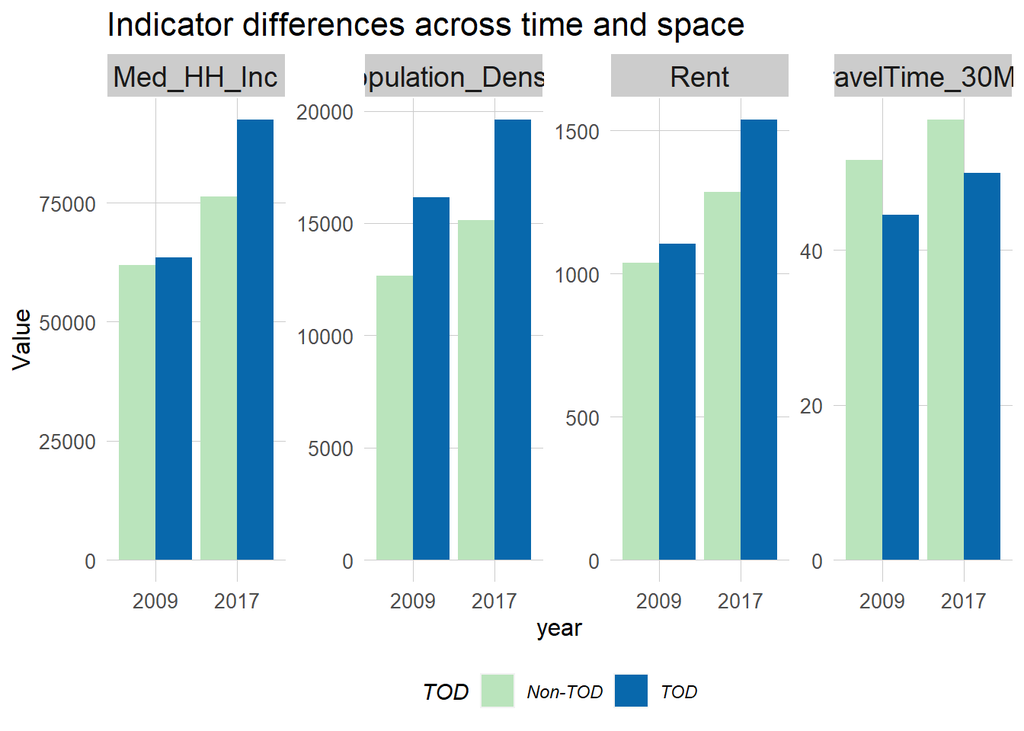

```r
  #  %>%
  # kbl() %>%
  # kable_styling(bootstrap_options = c("striped", "hover"))

# --- TOD Indicator Plots ------

# Creating bar charts that compare the four census variables between 2009 and 2017 and TOD and non-TOD tracts
allTracts.Summary %>%
  gather(Variable, Value, -year, -TOD) %>%
  ggplot(aes(year, Value, fill = TOD)) +
  geom_bar(stat = "identity", position = "dodge") +
  facet_wrap(~Variable, scales = "free", ncol=5) +
  scale_fill_manual(values = c("#bae4bc", "#0868ac")) +
  labs(title = "Indicator differences across time and space") +
  plotTheme() + theme(legend.position="bottom")
```

## Population and Rent by Station

Now, we will visualize the relationwhips of Population and Rent across Transit-Oriented Development in Washington, DC.

The highest Populations appear to be in the center of the city, with more than 50,000 people living within .5 miles. The lowest Populaitons are under 10,000.

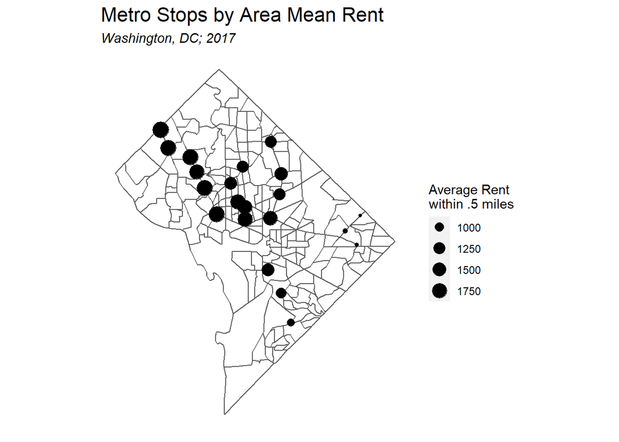

```r
## Graduated symbol maps ## -------
# Define buffer around Metro stops
station_buffer <-
  st_transform(metroStops, ('ESRI:102728')) %>%
  st_buffer(2600) %>%
  dplyr::select(NAME)

#join the tracts to the newly created buffer
j <-
  st_join(tracts17, station_buffer) %>%
  filter(!is.na(NAME))

#Summarize average rent by station
rentByStation <-
  j %>%
  group_by(NAME) %>%
  summarize(Rent = mean(MedRent)) %>%
  st_drop_geometry() %>%
  left_join(metroStops) %>%
  st_sf()

#plot results
ggplot() +
  geom_sf(data=tracts17, fill="white") +
  geom_sf(data=rentByStation, aes(size=Rent)) +
  labs(title="Metro Stops by Area Mean Rent",
       subtitle="Washington, DC; 2017",
       size = "Average Rent \nwithin .5 miles") +
  mapTheme()
```

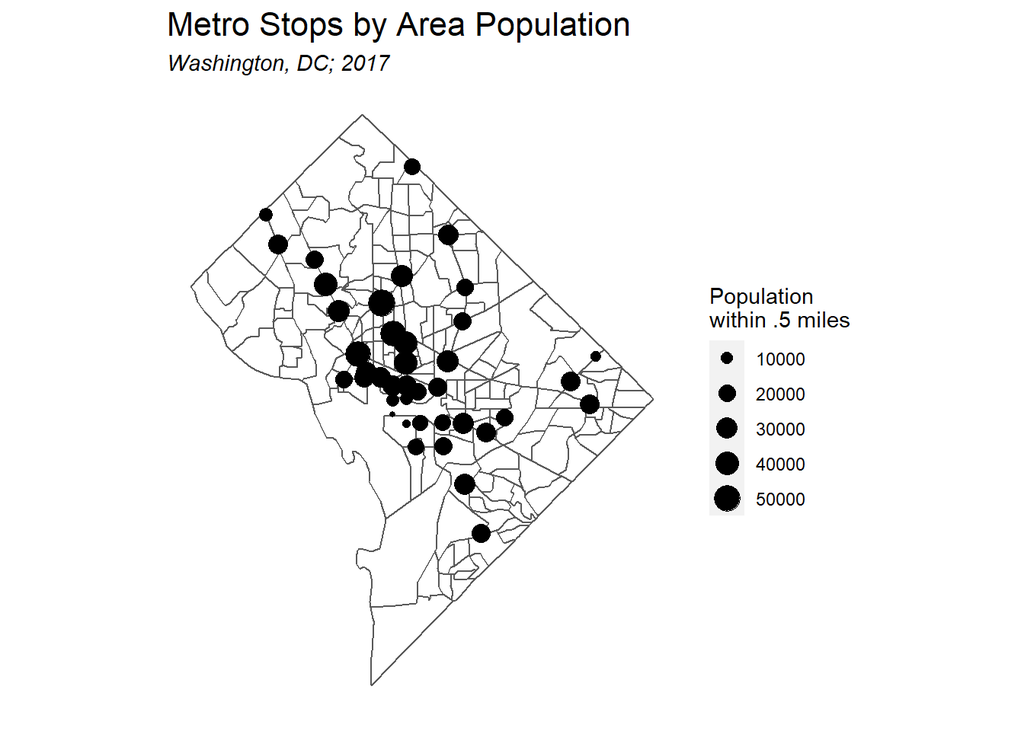

```r
#Summarize total population by station
popByStation <-
  j %>%
  group_by(NAME) %>%
  summarize(sumPop = sum(TotalPop)) %>%
  st_drop_geometry() %>%
  left_join(metroStops) %>%
  st_sf()

#plot results
ggplot() +
  geom_sf(data=tracts17, fill="white") +
  geom_sf(data=popByStation, aes(size=sumPop)) +
  labs(title="Metro Stops by Area Population",
       subtitle="Washington, DC; 2017",
       size = "Population \nwithin .5 miles") +
  mapTheme()
```

### Policy Suggestion

The Metro Stops by Area Population map shows drastic differences in population near transit. Policy makers should consider targetting more maintenance and operations funding to stations with higher populations nearby. These stations are like to have more wear/tear since they are likely to be used by more people.

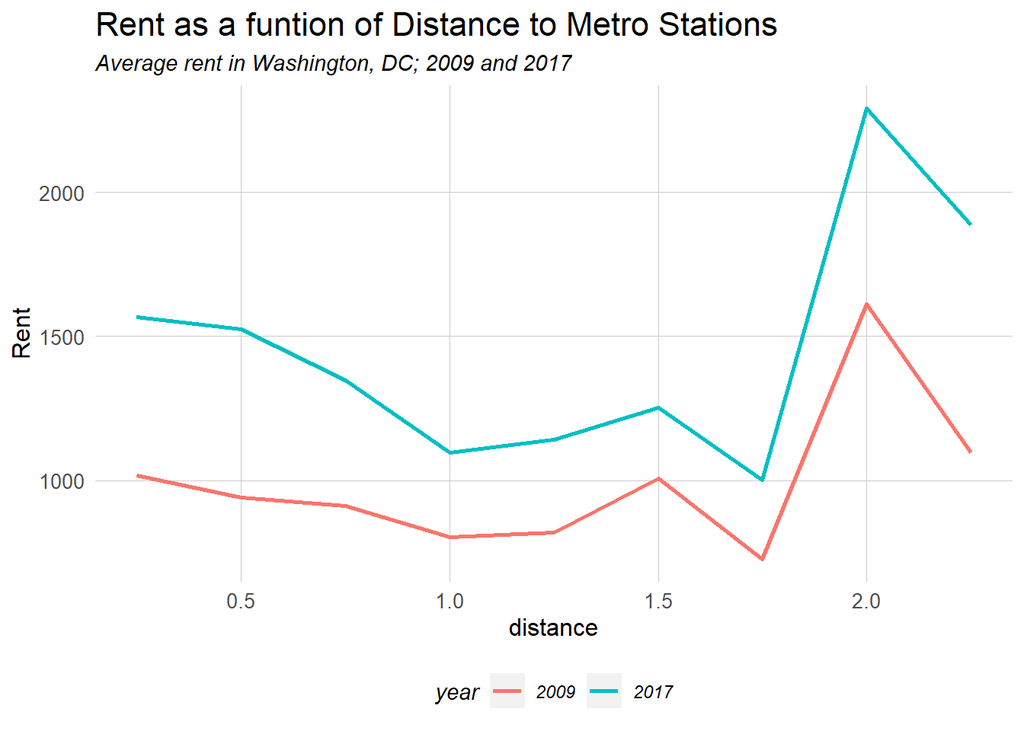

```r
## Analyze daya by distance from a train station.

#establish multi-ring buffers
buffers <- multipleRingBuffer(metroStops, 21120, 1320) #buffer every .25 miles (1,320 ft)

#join census tract data by buffers to assign a tiered distance for every .25 miles (1,320 ft)
allTracts.rings <-
  st_join(st_centroid(dplyr::select(allTracts, GEOID, year)),
          multipleRingBuffer(st_union(metroStops), 21120, 1320)) %>%
  st_drop_geometry() %>%
  left_join(dplyr::select(allTracts, GEOID, MedRent, year),
            by=c("GEOID"="GEOID", "year"="year")) %>%
  st_sf() %>%
  mutate(distance = distance / 5280) #convert to miles

#summarise data to obtain average rent
allTracts.rings_summary <-
  allTracts.rings %>%
  st_drop_geometry() %>%
  group_by(year, distance) %>%
  summarize(Rent = mean(MedRent, na.rm=T))

#plot results
ggplot(subset(allTracts.rings_summary, distance < 2.5), aes(x = distance, y = Rent)) +
  geom_line(size = 1, aes(color = year)) +
  labs(title="Rent as a funtion of Distance to Metro Stations",
       subtitle = "Average rent in Washington, DC; 2009 and 2017") +
plotTheme() + theme(legend.position="bottom")
```

If we compare rent for 2009 and 2017 as a function of Distance from Metro stops, we see that the highest rents are consistently present within a 1/4 mile from transit stations and 2 miles from transit stations.

### Policy Suggestion

Because Rent tends to be higher futher away from transit *and* near transit, these sites should be targeting for more affordable housing development.

## Relationships: Rent, Crime, and Transit Access

```r
#download crime data
crime <- st_read("https://opendata.arcgis.com/datasets/6af5cb8dc38e4bcbac8168b27ee104aa_38.geojson") %>%
  st_transform('ESRI:102728')
```

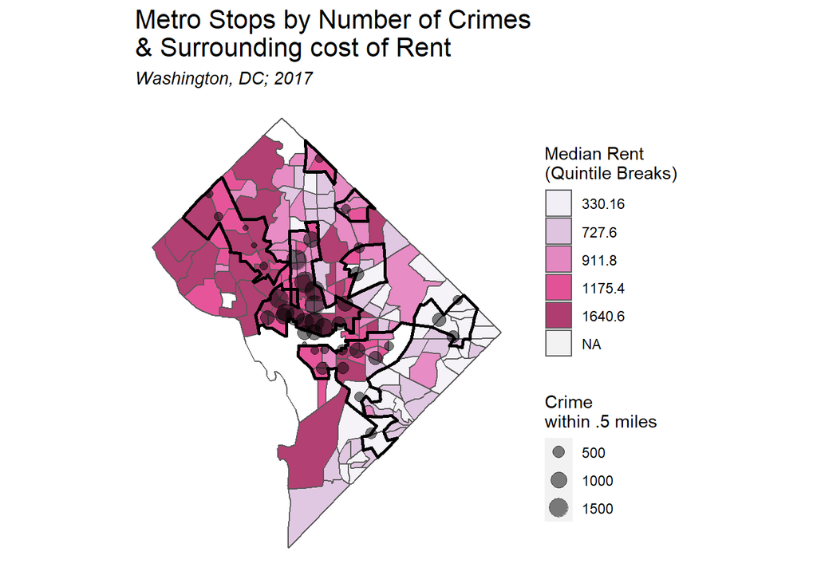

```r
#join crimes to station buffers
j_crime <-
  st_join(crime, station_buffer) %>%
  filter(!is.na(NAME))

#summarize crime counts by station
crimeByStation <-
  j_crime %>%
  group_by(NAME) %>%
  summarize(crime_count = n())%>%
  st_drop_geometry() %>%
  left_join(metroStops) %>%
  st_sf()

#visualize crime by station and rent
ggplot() +
  geom_sf(data=tracts17, aes(fill = q5(MedRent)), alpha = .75) +
  geom_sf(data=crimeByStation, aes(size=crime_count), alpha = .5) +
  geom_sf(data = TOD_outline, size = 1, color = "black", fill = NA) +
  scale_fill_manual(values = c("#f1eef6", "#d7b5d8", "#df65b0", "#dd1c77", "#980043"),
                    name = "Median Rent\n(Quintile Breaks)",
                    labels = qBr(allTracts.group, "MedRent")) +
  labs(title="Metro Stops by Number of Crimes \n& Surrounding cost of Rent",
       subtitle="Washington, DC; 2017",
       size = "Crime\nwithin .5 miles") +
  mapTheme()
```

Finally, we visualize relationhips between crime, transit, and cost of rent. The most cimes in DC seem to not necessarity be correlated with high rent, but with with populaiton and populaiton density (in accordance with maps presented further above).

We should also beware that crimes from this dataset could be biased. Data show that minority populaitons are twice as likely to be stopped by posice officers in some cases (https://www.vanityfair.com/news/2016/07/data-police-racial-bias). Thus, crimes committed by white people are 50% less likely to be present in this data.

### Policy Suggestion

To address this bias and reduce crime at the same time, there are several ways to address crime *without increasing police presence or violence*. These strategies are from The Urban Institute (https://www.urban.org/urban-wire/five-ways-reduce-crime). Strageties include:

- Expanding use of drug courts as social service programs to reduce drug use.
- Make use of DNA evidence
- Help ex-offenders find secure living-wage employment
- Monitor public surveillance cameras
- Connect returning prisoners to stable housing